# Introduction to birddog

Source: [`vignettes/introduction_birddog.Rmd`](https://github.com/roneyfraga/birddog/blob/HEAD/vignettes/introduction_birddog.Rmd)

## Overview

`birddog` helps you detect emergence and trace trajectories in scientific literature and patents. It reads datasets from OpenAlex and Web of Science (WoS), builds citation-based networks, identifies groups, and summarizes their dynamics.

The stable release is on CRAN. The development version is available on GitHub: https://github.com/roneyfraga/birddog.

### Methodological workflow

[figure not shown]

## Installation

```r
# stable version (CRAN)
install.packages("birddog")

# development version (GitHub)
# install.packages("remotes")
remotes::install_github("roneyfraga/birddog")
```

```r
library(birddog)
```

## Data sources

`birddog` supports two main data sources:

- [OpenAlex](https://openalex.org/): browser search with CSV export, or API via openalexR.
- [Web of Science](https://www.webofscience.com/wos/woscc/smart-search): multiple export formats (`.bib`, `.ris`, plain-text `.txt`, tab-delimited `.txt`).

### OpenAlex via API or CSV

```r
library(openalexR)

# Fetch works from OpenAlex API
url_api <- "https://api.openalex.org/works?page=1&filter=primary_location.source.id:s121026525"

openalexR::oa_request(query_url = url_api) |>
  openalexR::oa2df(entity = "works") |>
  birddog::read_openalex(format = "api") ->
  M

# Or from a CSV export
M <- birddog::read_openalex("path/to/openalex-export.csv", format = "csv")
```

### Web of Science (WoS)

```r
# BibTeX
M <- birddog::read_wos("path/to/savedrecs.bib", format = "bib")

# RIS
M <- birddog::read_wos("path/to/savedrecs.ris", format = "ris")

# Plain text
M <- birddog::read_wos("path/to/savedrecs.txt", format = "txt-plain-text")

# Tab-delimited
M <- birddog::read_wos("path/to/savedrecs.txt", format = "txt-tab-delimited")
```

## Example dataset

We use a biogas dataset from OpenAlex with 57,734 documents as a running example.

```r
# Download from OpenAlex (~15 min)
query_oa <- "( biogas )"

openalexR::oa_fetch(
  entity = "works",
  title_and_abstract.search = query_oa,
  verbose = TRUE
) ->
  papers

M <- birddog::read_openalex(papers, format = "api")
```

```r
# Pre-computed dataset
url_m <- "https://roneyfraga.com/volume/keep_it/biogas-data/M.rds"
M <- readRDS(url(url_m))
```

```r
dplyr::glimpse(M)
```

```
#> Rows: 57,734
#> Columns: 55
#> $ id                          <chr> "https://openalex.org/W2072823483", "https…
#> $ id_short                    <chr> "W2072823483", "W2109587007", "W2032792259…
#> $ SR                          <chr> "W2072823483", "W2109587007", "W2032792259…
#> $ PY                          <int> 2009, 2008, 2009, 2011, 2018, 2015, 2006, …
#> $ TC                          <int> 2672, 2542, 1616, 1228, 1111, 1540, 667, 9…
#> $ TI                          <chr> "Biogas production: current state and pers…
#> $ DI                          <chr> "https://doi.org/10.1007/s00253-009-2246-7…
#> $ AB                          <chr> NA, "Lignocelluloses are often a major or …
#> $ CR                          <chr> "W1417235137;W1503353321;W1506760845;W1529…
#> $ DE                          <chr> "biogas;digestate;renewable natural gas", …
#> $ AU                          <chr> "PETER WEILAND", "MOHAMMAD J. TAHERZADEH;K…
#> $ DB                          <chr> "openalex_api", "openalex_api", "openalex_…
#> $ title                       <chr> "Biogas production: current state and pers…
```

[output cut: 42 more lines]

## Citation network

Build a citation network to map the relationships between documents. Direct citation captures time-ordered influence; bibliographic coupling groups papers that share references.

```r
net <- birddog::sniff_network(M, type = "direct citation")
```

```r
net |>
  tidygraph::activate(nodes) |>
  dplyr::select(name, AU, PY, TI, TC) |>
  dplyr::arrange(dplyr::desc(TC))
```

```
#> # A tbl_graph: 29490 nodes and 197059 edges
#> #
#> # A directed simple graph with 297 components
#> #
#> # Node Data: 29,490 × 5 (active)
#>    name        AU                                                 PY TI       TC
#>    <chr>       <chr>                                           <int> <chr> <int>
#>  1 W2072823483 PETER WEILAND                                    2009 Biog…  2672
#>  2 W2109587007 MOHAMMAD J. TAHERZADEH;KEIKHOSRO KARIMI          2008 Pret…  2542
#>  3 W2125363721 DAVID SCHMEIDLER                                 1969 The …  1873
#>  4 W2089274821 İRINI ANGELIDAKI;M. M. ALVES;DAVID BOLZONELLA;…  2009 Defi…  1857
#>  5 W2075740579 PERRY L. MCCARTY;JAEHO BAE;JEONGHWAN KIM         2011 Dome…  1670
#>  6 W2032792259 JENS BO HOLM‐NIELSEN;TEODORITA AL SEADI;PIOTR …  2009 The …  1616
#>  7 W2024397118 CHUNLAN MAO;YONGZHONG FENG;XIAOJIAO WANG;GUANG…  2015 Revi…  1540
#>  8 W2043402970 YI ZHENG;JIA ZHAO;FUQING XU;YEBO LI              2014 Pret…  1238
#>  9 W2018893323 ELINE RYCKEBOSCH;MARGRIET DROUILLON;HAN VERVAE…  2011 Tech…  1228
#> 10 W2111419835 CUNSHENG ZHANG;HAIJIA SU;JAN BAEYENS;TIANWEI T…  2014 Revi…  1173
#> # ℹ 29,480 more rows
#> #
#> # Edge Data: 197,059 × 2
#>    from    to
#>   <int> <int>
#> 1     1    48
#> 2     1    80
#> 3     1    77
#> # ℹ 197,056 more rows
```

## Components

Identify connected components to eliminate disconnected documents that do not share the same bibliographic references.

```r
comps <- birddog::sniff_components(net)
```

```r
comps$components |>
  dplyr::slice_head(n = 5) |>
  gt::gt()
```

| component | quantity_publications | average_age |
| --- | --- | --- |
| c1 | 28820 | 2016.840 |
| c2 | 27 | 2018.444 |
| c3 | 7 | 2014.857 |
| c4 | 7 | 2011.857 |
| c5 | 7 | 2019.286 |

## Groups (community detection)

Detect research communities within the citation network. Each group represents a cluster of related publications.

```r
groups <- birddog::sniff_groups(
  comps,
  algorithm = "fast_greedy",
  min_group_size = 30,
  seed = 888L
)
```

```r
groups$aggregate |>
  gt::gt()
```

| group | quantity_papers | average_age |
| --- | --- | --- |
| c1g1 | 6448 | 2017.027 |
| c1g2 | 4157 | 2015.351 |
| c1g3 | 2960 | 2016.728 |
| c1g4 | 2893 | 2017.972 |
| c1g5 | 1937 | 2017.712 |
| c1g6 | 1805 | 2015.425 |
| c1g7 | 1588 | 2017.868 |
| c1g8 | 1529 | 2017.650 |
| c1g9 | 1289 | 2016.700 |
| c1g10 | 924 | 2017.745 |
| c1g11 | 853 | 2017.613 |
| c1g12 | 818 | 2017.555 |
| c1g13 | 598 | 2015.572 |
| c1g14 | 442 | 2017.713 |
| c1g15 | 295 | 2011.854 |
| c1g16 | 47 | 2013.319 |
| c1g17 | 31 | 2019.548 |

### Group attributes

Summarize group-level statistics including publication trends and growth rates.

```r
# ~2 min
groups_attributes <- birddog::sniff_groups_attributes(
  groups,
  growth_rate_period = 2010:2024,
  show_results = FALSE
)
```

```r
groups_attributes$attributes_table
```

Groups Attributes

Group

Publications

Average age<sup>1</sup>

Growth rate<sup>2</sup>

Doubling time<sup>3</sup>

Horizon plot<sup>4</sup>

c1g1

6448

2017+0m

6.5

11y+1m

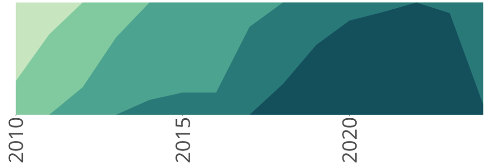

c1g2

4157

2015+4m

4.9

15y+7m

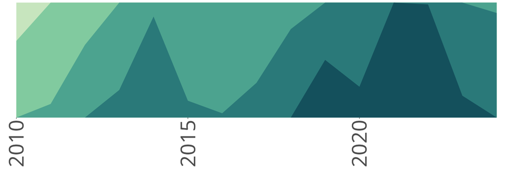

c1g3

2960

2016+9m

3.7

19y+2m

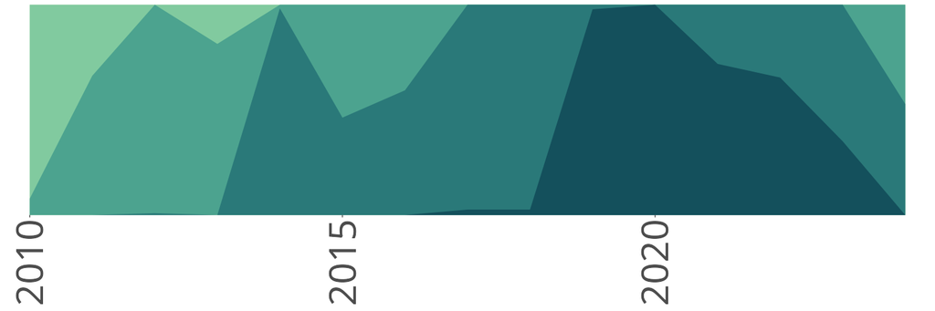

c1g4

2893

2017+12m

9.0

8y

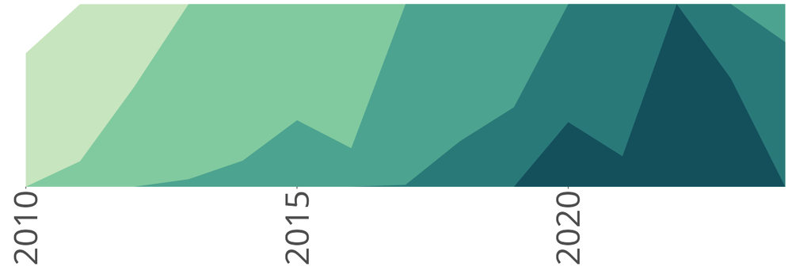

c1g5

1937

2017+9m

10.0

7y+4m

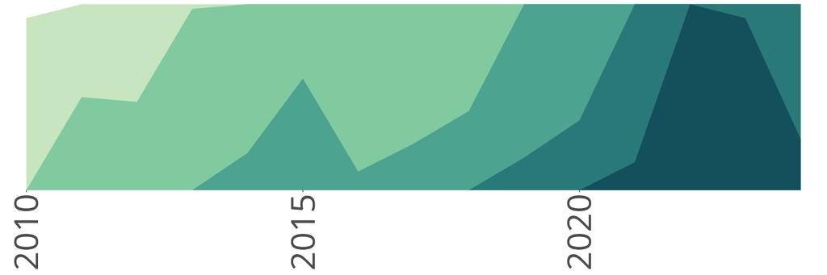

c1g6

1805

2015+5m

2.9

24y+6m

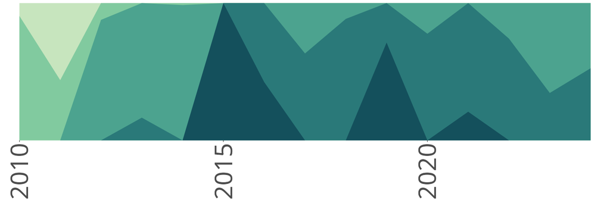

c1g7

1588

2017+10m

8.6

8y+5m

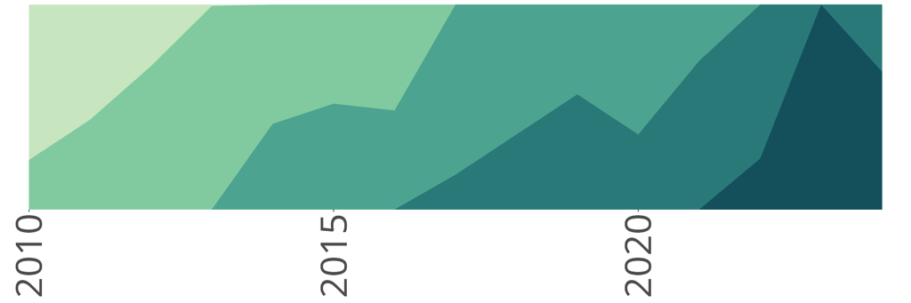

c1g8

1529

2017+8m

11.2

7y+7m

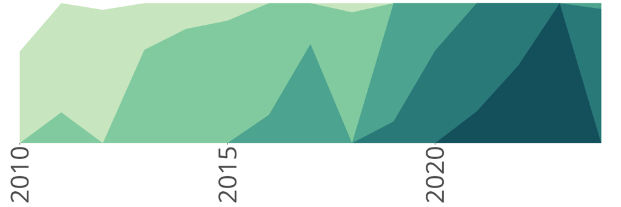

c1g9

1289

2016+8m

6.0

12y+11m

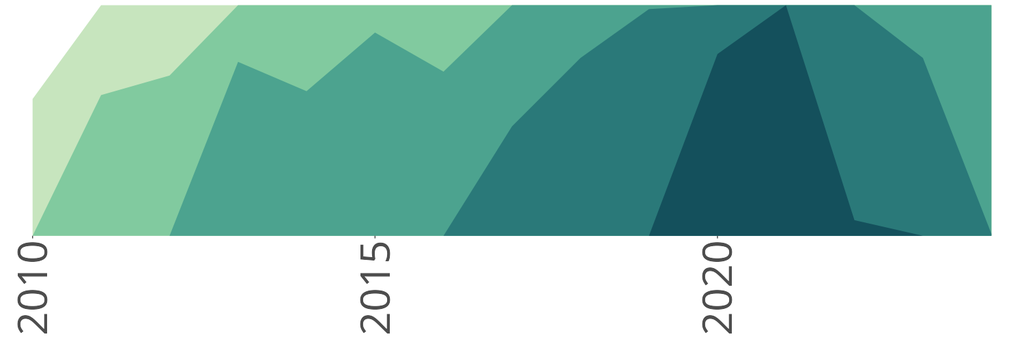

c1g10

924

2017+9m

7.1

10y+1m

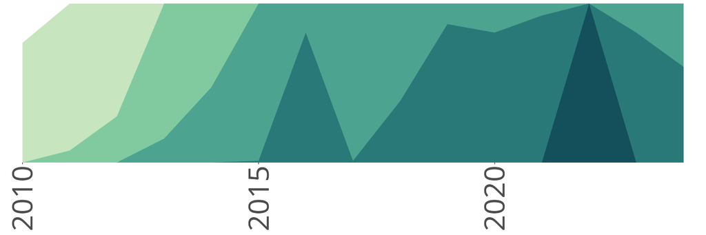

c1g11

853

2017+7m

6.9

10y+5m

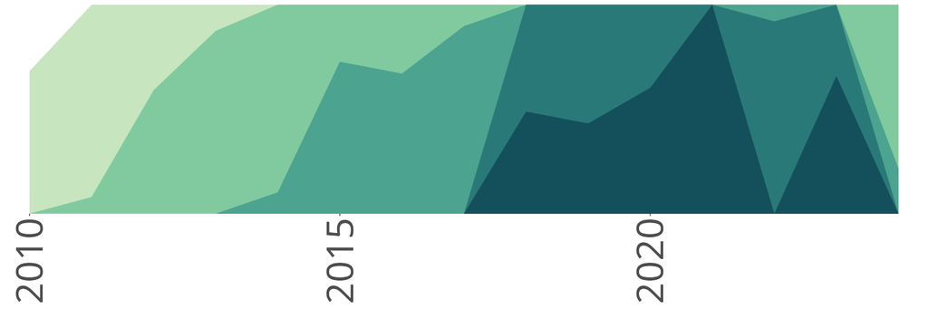

c1g12

818

2017+7m

8.4

9y+7m

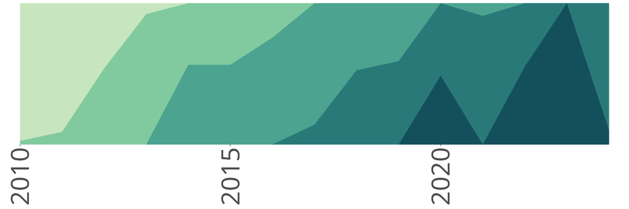

c1g13

598

2015+7m

4.6

15y+4m

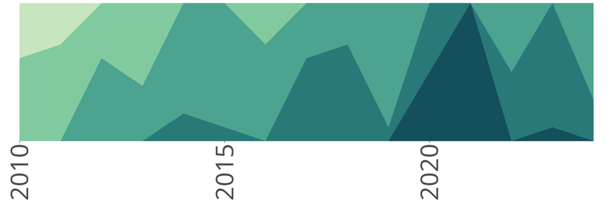

c1g14

442

2017+9m

11.3

6y+6m

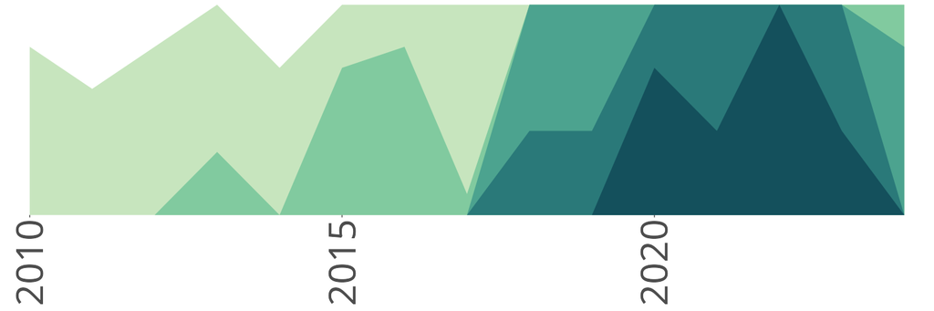

c1g15

295

2011+10m

4.8

15y+8m

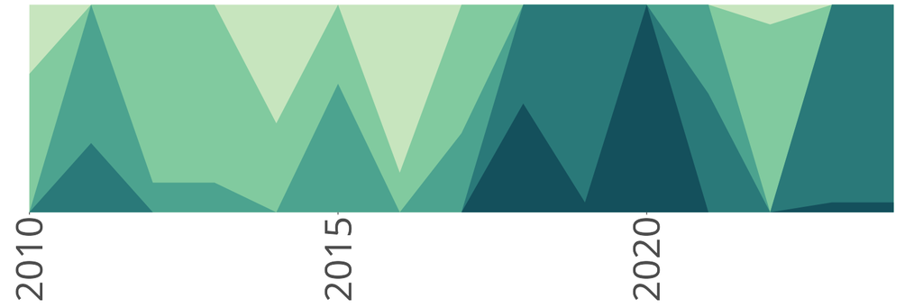

c1g16

47

2013+4m

1.3

54y+6m

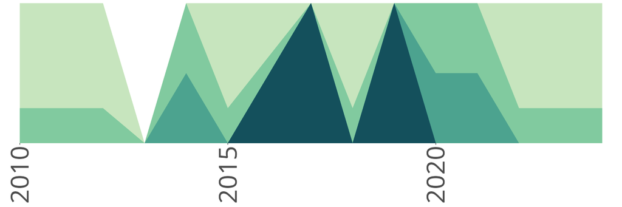

c1g17

31

2019+7m

16.3

5y+7m

[figure not shown]

<sup>1</sup> Average publication year: For example, '2016+7m' means that the articles were published, on average, in 2016 plus seven months.

<sup>2</sup> Growth rate percentage year. Calculated by exp(b1)-1 where b1 is the econometric model coefficient. Time span, 2010 until 2024.

<sup>3</sup> y = years, m = months. Calculated by ln(2)/b1 where b1 is the econometric model coefficient.

<sup>4</sup> Publications between 2010 and 2024. Chart type horizon plot.

**Source**: OpenAlex. Data extracted, organized and estimated by the authors.

### Group keywords

Explore the most frequent keywords in each group.

```r
groups_keywords <- birddog::sniff_groups_keywords(groups)

groups_keywords |>
  dplyr::filter(group %in% c('c1g1', 'c1g2', 'c1g3')) |>
  gt::gt()
```

| group | term_freq | term_tfidf |
| --- | --- | --- |
| c1g1 | biogas (5702); biogas production (2089); digestion (942); mesophile (785); food waste (644); biodegradable waste (563); cow dung (515); sewage sludge (498); hydraulic retention time (336); digestate (… | food waste [0.004] (644); gompertz function [0.004] (150); hyacinth [0.0036] (168); lignocellulosic biomass [0.0035] (261); steam explosion [0.003] (69); total dissolved solids [0.003] (228); digestio… |
| c1g2 | biogas (3485); biogas production (847); cow dung (261); (212); biodegradable waste (193); energy source (156); animal waste (146); renewable resource (134); mesophile (120); firewood (109); digestion … | firewood [0.0069] (109); stove [0.0051] (95); diesel generator [0.0048] (46); emergy [0.0048] (33); rural electrification [0.0046] (44); dome (geology) [0.0045] (31); microgrid [0.0044] (50); kerosene… |
| c1g3 | biogas (2368); biogas production (588); energy crop (281); silage (221); (217); digestate (213); food waste (97); biodegradable waste (87); cogeneration (84); renewable resource (75); digestion (68); … | hectare [0.0072] (58); energy crop [0.0049] (281); sweet sorghum [0.0044] (22); arable land [0.0043] (41); silage [0.0039] (221); phalaris arundinacea [0.0033] (11); agricultural land [0.0031] (13); a… |

### Group NLP terms

Extract key phrases from abstracts using natural language processing.

```r
# ~30 min
groups_terms <- birddog::sniff_groups_terms(groups, algorithm = "phrase")
```

```r
groups_terms$terms_table |>
  dplyr::slice_head(n = 3) |>
  gt::gt()
```

| group | term_freq | term_tfidf |
| --- | --- | --- |
| c1g1 | biogas production (6713); anaerobic digestion (5247); methane production (1419); food waste (1344); anaerobic co-digestion (1005); methane yield (922); biogas yield (879); cow dung (818); solid waste … | water hyacinth [0.0017] (633); anaerobic digestion [0.0016] (5247); thermal pretreatment [0.0013] (123); wheat straw [0.0010] (382); anaerobic co-digestion [0.0010] (1005); hydrodynamic cavitation [0.… |
| c1g2 | biogas production (1747); renewable energy (1348); anaerobic digestion (988); biogas plants (726); biogas plant (654); biogas technology (638); cow dung (572); energy sources (512); rural areas (388);… | technology adoption [0.0022] (83); rural households [0.0021] (102); household biogas [0.0020] (241); domestic biogas [0.0018] (91); biogas digesters [0.0018] (253); cassava peels [0.0018] (87); biogas… |
| c1g3 | biogas production (1711); anaerobic digestion (1040); biogas plants (1010); renewable energy (656); biogas plant (638); life cycle (420); greenhouse gas (351); agricultural biogas (321); energy produc… | cross ref [0.0072] (191); lt ;w [0.0053] (140); lt ;w :lsdexception [0.0041] (109); ;w :lsdexception [0.0041] (109); 2021 cross [0.0031] (82); cup plant [0.0030] (78); 2020 cross [0.0025] (67); agricu… |

### Hubs

Classify documents by their role in the network using the Zi-Pi method. Hub documents connect different research communities.

```r
# ~20 min
groups_hubs <- birddog::sniff_groups_hubs(groups)
```

```r
groups_hubs |>
  dplyr::filter(zone != "noHub") |>
  dplyr::mutate(Zi = round(Zi, 2), Pi = round(Pi, 2)) |>
  dplyr::arrange(dplyr::desc(zone), dplyr::desc(Zi)) |>
  dplyr::slice_head(n = 15) |>
  gt::gt() |>
  gt::text_transform(
    locations = gt::cells_body(columns = name),
    fn = function(x) {
      glue::glue('<a href="https://openalex.org/{x}" target="_blank">{x}</a>')
    }
  )
```

| group | name | TC | Ki | ki | Zi | Pi | zone |
| --- | --- | --- | --- | --- | --- | --- | --- |
| c1g1 | W2024397118 | 1540 | 524 | 243 | 17.45 | 0.75 | R7 |
| c1g6 | W2072823483 | 2672 | 1101 | 217 | 17.20 | 0.87 | R7 |
| c1g3 | W1972749747 | 737 | 344 | 138 | 13.67 | 0.78 | R7 |
| c1g3 | W2794649776 | 1111 | 523 | 127 | 12.54 | 0.86 | R7 |
| c1g1 | W1606100078 | 939 | 410 | 154 | 10.90 | 0.81 | R7 |
| c1g5 | W2032792259 | 1616 | 551 | 97 | 9.03 | 0.88 | R7 |
| c1g13 | W1985829371 | 227 | 89 | 34 | 8.20 | 0.78 | R7 |
| c1g1 | W2730727434 | 527 | 208 | 79 | 5.38 | 0.79 | R7 |
| c1g12 | W2029511769 | 308 | 96 | 34 | 5.04 | 0.78 | R7 |
| c1g13 | W2338842862 | 132 | 50 | 21 | 4.83 | 0.78 | R7 |
| c1g1 | W2049325764 | 385 | 163 | 64 | 4.27 | 0.79 | R7 |
| c1g5 | W2156879463 | 437 | 119 | 45 | 3.96 | 0.78 | R7 |
| c1g3 | W2798048710 | 329 | 160 | 43 | 3.93 | 0.82 | R7 |
| c1g1 | W2276289647 | 292 | 131 | 59 | 3.90 | 0.76 | R7 |
| c1g8 | W1912164921 | 488 | 132 | 34 | 3.82 | 0.85 | R7 |

### Group influence

`sniff_groups_influence()` lifts the internal citations to the group level and measures how much each group’s output flows into every other’s. Influence is directional – if group B’s papers cite group A’s, knowledge flows A to B – so the cross-citation matrix is asymmetric, the directed twin of the confluence matrix. Each ordered pair carries four size-corrected indices (debt, audience, Salton, surprise); the net flow (citations one way minus the reciprocal) and the balance (received minus made) classify every group as a source, a broker or a sink.

```r
influence <- birddog::sniff_groups_influence(groups)

influence$groups |>
  gt::gt()
```

| group | received | made | balance | role |
| --- | --- | --- | --- | --- |
| c1g6 | 15071 | 12833 | 2238 | source |
| c1g3 | 21641 | 19449 | 2192 | source |
| c1g4 | 27778 | 27130 | 648 | source |
| c1g1 | 47818 | 47256 | 562 | source |
| c1g5 | 10840 | 10567 | 273 | source |
| c1g16 | 131 | 135 | -4 | sink |
| c1g17 | 73 | 79 | -6 | sink |
| c1g10 | 6645 | 6661 | -16 | sink |
| c1g15 | 1104 | 1128 | -24 | sink |
| c1g13 | 2278 | 2349 | -71 | sink |
| c1g11 | 1621 | 1733 | -112 | sink |
| c1g14 | 3006 | 3631 | -625 | sink |
| c1g9 | 8796 | 9536 | -740 | sink |
| c1g12 | 3803 | 4757 | -954 | sink |
| c1g2 | 26410 | 27426 | -1016 | sink |
| c1g8 | 8601 | 9660 | -1059 | sink |
| c1g7 | 10493 | 11779 | -1286 | sink |

`plot_groups_influence_matrix()` is the directed counterpart of `plot_trajectory_confluence_matrix()`: rows are the citing group (“is influenced”), columns the cited group (“the influencer”), and a cell and its mirror across the diagonal are the two directions of one pair. Because intra-group citation dominates, `self = FALSE` drops the diagonal and sharpens the between-group surprise.

```r
influence_between <- birddog::sniff_groups_influence(groups, self = FALSE)

birddog::plot_groups_influence_matrix(influence_between, fill = "surprise", x_angle = 45)
```

[figure not shown]

## Indexes

`birddog` tracks each group’s pace of change and thematic spread as year-by-year indexes.

### Citation Cycle Time

Measure the pace of change in each group by tracking how old the cited references are over time.

```r
# ~1.5 min
groups_cct <- birddog::sniff_cct(
  groups,
  scope = "groups",
  start_year = 2000,
  end_year = 2024
)

groups_cct$plots[["c1g3"]]
```

[figure not shown]

### Entropy

Track keyword diversity within each group over time. Increasing entropy signals thematic diversification; decreasing entropy signals convergence.

```r
groups_entropy <- birddog::sniff_entropy(
  groups,
  scope = "groups",
  start_year = 2000,
  end_year = 2024
)

groups_entropy$plots[["c1g3"]]
```

[figure not shown]

## Group lineage

Groups are a stock: each year’s community is recomputed from scratch. To trace how a community evolves, `birddog` builds cumulative networks year by year and tracks each final-year group backwards through the earlier cuts.

```r
# ~2 min
groups_cumulative <- birddog::sniff_groups_cumulative(groups)
```

`plot_groups_map()` lays out the final cumulative network and colours every document by its group.

```r
birddog::plot_groups_map(groups_cumulative)
```

[figure not shown]

`sniff_groups_lineage()` tracks each final-year group backwards through the cumulative cuts; `plot_groups_lineage_2d()` and `plot_groups_lineage_3d()` draw one group’s lineage at a time.

```r
suppressMessages({
  groups_lineage <- birddog::sniff_groups_lineage(groups_cumulative)
})

birddog::plot_groups_lineage_2d(
  groups_lineage,
  group = "c1g3",
  label_vertical_position = -2
)

birddog::plot_groups_lineage_3d(
  groups_lineage,
  group = "c1g3"
)
```

[figure not shown]

## Trajectories

The lineage view follows one group at a time. Trajectories are a flow: `sniff_trajectory_dag()` reads the whole cumulative-clustering history at once and builds the temporal DAG of cluster-year nodes.

```r
dag <- birddog::sniff_trajectory_dag(groups_lineage)

dag
```

```
#> <birddog_dag> 410 group-year nodes, 537 edges, 1993-2025
```

`plot_groups_per_year()` counts the groups alive in each yearly cut; `plot_trajectory_dag()` draws the full node-and-edge DAG.

```r
birddog::plot_groups_per_year(dag)
```

[figure not shown]

```r
birddog::plot_trajectory_dag(dag)
```

[figure not shown]

### Braid

`sniff_trajectory_braid()` decomposes that DAG into trajectories. A trajectory that reaches the final year is **central** (one per final group, named `tr::c1g1`, `tr::c1g2`, and so on). Every other trajectory is **intermediate** (`tr1` … `trN`, stored as `type == "absorbed"`): it merges into a central one before the end. Groups are stock, trajectories are flow.

```r
braid <- birddog::sniff_trajectory_braid(dag)

braid
```

```
#> <birddog_flow> 17 central + 68 absorbed trajectories, last year 2025
#> # A tibble: 5 × 4
#>   traj_id  start   end  size
#>   <chr>    <int> <int> <int>
#> 1 tr::c1g1  2010  2025  9933
#> 2 tr::c1g2  2007  2025  6327
#> 3 tr::c1g3  2017  2025  4985
#> 4 tr::c1g4  2006  2025  4834
#> 5 tr::c1g6  2001  2025  4467
```

`braid$trajectories` has one row per trajectory. Absorption is transitive, so the intermediate trajectories form a confluence tree under the centrals.

`subset()` focuses a flow on a watershed – a central trajectory and its whole tributary subtree – or on any predicate over `braid$trajectories`, and the result is still a valid flow (the pruning call is recorded and shown when you print it).

```r
# keep the central of group c1g3 and every trajectory that feeds it
watershed <- subset(braid, target = "tr::c1g3")

watershed
```

```
#> <birddog_flow> 1 central + 2 absorbed trajectories, last year 2025
#> (pruned: subset.birddog_flow(braid, target = "tr::c1g3"))
#> # A tibble: 1 × 4
#>   traj_id  start   end  size
#>   <chr>    <int> <int> <int>
#> 1 tr::c1g3  2017  2025  4985
```

### Channel

`sniff_trajectory_channel()` is a sibling detector over the same DAG. Instead of braiding tributaries into each central, it routes one global optimal-path backbone per final group, an alternative decomposition that keeps the same `birddog_flow` contract.

```r
channel <- birddog::sniff_trajectory_channel(dag)

channel
```

```
#> <birddog_flow> 17 central + 84 absorbed trajectories, last year 2025
#> # A tibble: 5 × 4
#>   traj_id  start   end  size
#>   <chr>    <int> <int> <int>
#> 1 tr::c1g1  2024  2025  6692
#> 2 tr::c1g2  2016  2025  5631
#> 3 tr::c1g3  2021  2025  4381
#> 4 tr::c1g4  2020  2025  4321
#> 5 tr::c1g6  2017  2025  3953
```

### Confluence

`sniff_trajectory_confluence()` turns the flow into render-ready data and `plot_trajectory_confluence()` draws the whole forest: each central trajectory is a river, each intermediate trajectory a tributary merging in at its handoff year.

```r
conf <- birddog::sniff_trajectory_confluence(braid)

birddog::plot_trajectory_confluence(conf, target = c('tr::c1g1', 'tr::c1g2', 'tr::c1g3'))
```

[figure not shown]

### Trajectory lines

`plot_trajectory_lines_2d()` is the line counterpart of the confluence delta: every trajectory is a variable-width line on the year-aware Sugiyama layout, widening with the documents it accumulates. Targeting a central draws it and the trajectories that feed it; the legend reports how many papers of each feeder’s terminal cohort reached the final group. Where `plot_trajectory_confluence(conf, target = ...)` keeps only the direct tributaries (`depth = 1`), the lines view follows the whole tributary subtree – feeders and feeders of feeders – so a targeted central shows more lines here than in the confluence delta. Open the delta to every depth with `plot_trajectory_confluence(conf, target = "tr::c1g3", depth = Inf)`.

```r
birddog::plot_trajectory_lines_2d(braid, target = "tr::c1g3")
```

[figure not shown]

`plot_trajectory_lines_3d()` is the interactive plotly version of the same view: x = year, y = route (the Sugiyama branching coordinate), z = cumulative tracked documents.

```r
birddog::plot_trajectory_lines_3d(braid, target = "tr::c1g3")
```

[figure not shown]

### Where an intermediate trajectory’s papers go

A trajectory can stop before the final year, but with cumulative clustering its papers never leave the network: they are re-grouped each year. `sniff_trajectory_destination()` follows a trajectory’s terminal cohort forward and reports where the papers land, split by final group. Here `tr9` (2011-2017, handed off in 2018) is mostly captured by group `c1g3`: 336 of its 502 terminal papers end in `c1g3`’s final community, and none drop out of the network.

```r
# where do the papers of trajectory tr9 go?
dest <- birddog::sniff_trajectory_destination(braid, source = "tr9")

dest$destination
```

```
#> # A tibble: 13 × 3
#>    g_final     n    prop
#>    <chr>   <int>   <dbl>
#>  1 c1g3      336 0.669
#>  2 c1g1       60 0.120
#>  3 c1g6       39 0.0777
#>  4 c1g5       16 0.0319
#>  5 c1g13      13 0.0259
#>  6 c1g2       13 0.0259
#>  7 c1g15       6 0.0120
#>  8 c1g4        6 0.0120
#>  9 c1g11       5 0.00996
#> 10 c1g12       2 0.00398
#> 11 c1g14       2 0.00398
#> 12 c1g8        2 0.00398
#> 13 c1g9        2 0.00398
```

```r
birddog::plot_trajectory_dispersion(dest)
```

[figure not shown]

### Which trajectories formed a central one

The mirror of the previous analysis: stand at a central trajectory and ask which trajectories fed into it. `sniff_trajectory_formation()` returns the target’s direct tributaries in the confluence tree. `plot_trajectory_formation()` draws the target as a cumulative river with each feeder merging at its handoff year. Two feeders formed `tr::c1g3`: `tr9`, handed off in 2018, and `tr14`, handed off in 2022; the labels count each feeder’s papers that sit in the target’s final community.

```r
# which trajectories formed the central trajectory of group c1g3?
form <- birddog::sniff_trajectory_formation(braid, target = "tr::c1g3")

form$feeders
```

[output not shown]

```r
birddog::plot_trajectory_formation(form, max_feeders = 8)
```

[figure not shown]

### Documents transferred

`sniff_trajectory_destination()` and `sniff_trajectory_formation()` count the papers that crossed; `sniff_trajectory_contribution()` lists them. Given an intermediate trajectory, the year of its terminal cohort, and a central target, it returns one row per document with `in_target` flagging those that reached the target’s final-year community.

```r
# the terminal-cohort year of tr9 (its last node)
yr <- max(as.integer(sub("^y(\\d{4}).*", "\\1",
  braid$trajectories$nodes[[which(braid$trajectories$traj_id == "tr9")]])))

contrib <- birddog::sniff_trajectory_contribution(
  braid,
  source = "tr9",
  year = yr,
  target = "tr::c1g3"
)

contrib |>
  dplyr::summarise(documents = dplyr::n(), in_target = sum(in_target))
```

```
#> # A tibble: 1 × 2
#>   documents in_target
#>       <int>     <int>
#> 1       502       336
```

### Self-sufficiency

How much of each central trajectory grew on its own versus being a confluence of others? `sniff_trajectory_self_sufficiency()` reports the share of each central trajectory’s final-year community that was not delivered by an intermediate tributary: values near 1 mean the lineage grew endogenously; lower values mean it absorbed many documents from other communities.

```r
ss <- birddog::sniff_trajectory_self_sufficiency(braid)

ss |>
  dplyr::mutate(self_sufficiency = round(self_sufficiency, 2)) |>
  dplyr::slice_head(n = 10) |>
  gt::gt()
```

| central | group | final_size | inflow | self_sufficiency |
| --- | --- | --- | --- | --- |
| tr::c1g17 | c1g17 | 31 | 0 | 1.00 |
| tr::c1g4 | c1g4 | 2893 | 113 | 0.96 |
| tr::c1g7 | c1g7 | 1588 | 84 | 0.95 |
| tr::c1g9 | c1g9 | 1289 | 72 | 0.94 |
| tr::c1g5 | c1g5 | 1937 | 203 | 0.90 |
| tr::c1g10 | c1g10 | 924 | 102 | 0.89 |
| tr::c1g11 | c1g11 | 853 | 132 | 0.85 |
| tr::c1g6 | c1g6 | 1805 | 333 | 0.82 |
| tr::c1g2 | c1g2 | 4157 | 981 | 0.76 |
| tr::c1g13 | c1g13 | 598 | 178 | 0.70 |

### Trajectory dynamics

`sniff_trajectory_dynamics()` computes growth, novelty, recruitment and destination indicators per trajectory, then classifies each one into a dynamic state. Emergence: a central trajectory growing fast with a high share of recent papers. Convergence: an intermediate trajectory whose terminal cohort concentrates in a single central one. Divergence: an intermediate trajectory whose cohort scatters across several. Dormancy: a central trajectory that stalled, or an intermediate one whose cohort mostly drops out of the network. Central trajectories in between are classified as maturity.

```r
dyn <- birddog::sniff_trajectory_dynamics(braid)

birddog::plot_trajectory_dynamics(dyn)
```

[figure not shown]

### Per-trajectory lenses

`sniff_trajectory_dynamics()` left-joins optional lenses, each recomputed from the trajectory’s own documents and supplied as a per-year list-column: renewal pace (`sniff_trajectory_cct()`), keyword diversity (`sniff_trajectory_entropy()`) and hub roles (`sniff_trajectory_hubs()`). They are built from the corpus fields keyed by document id.

```r
keywords <- M |>
  dplyr::transmute(document_id = SR, keyword = DE) |>
  tidyr::separate_rows(keyword, sep = ";") |>
  dplyr::mutate(keyword = trimws(keyword)) |>
  dplyr::filter(keyword != "")

references <- M |>
  dplyr::transmute(document_id = SR, PY, CR) |>
  tidyr::separate_rows(CR, sep = ";") |>
  dplyr::mutate(CR = trimws(CR)) |>
  dplyr::filter(CR != "") |>
  dplyr::left_join(
    dplyr::distinct(groups_cct$tracked_cr_py, CR, .keep_all = TRUE), by = "CR") |>
  dplyr::filter(!is.na(CR_PY), PY > CR_PY) |>
  dplyr::transmute(document_id, ref_age = PY - CR_PY)

dyn <- birddog::sniff_trajectory_dynamics(
  braid,
  cct = birddog::sniff_trajectory_cct(braid, references),
  entropy = birddog::sniff_trajectory_entropy(braid, keywords),
  hubs = birddog::sniff_trajectory_hubs(braid, groups_hubs)
)
```

`sniff_trajectory_emergence_owners()` then credits each central trajectory’s emergence to its authors, surfacing the field’s leaders.

```r
authors <- M |>
  dplyr::transmute(document_id = SR, author = AU) |>
  tidyr::separate_rows(author, sep = ";") |>
  dplyr::mutate(author = trimws(author)) |>
  dplyr::filter(author != "")

birddog::sniff_trajectory_emergence_owners(braid, dyn, authors) |>
  dplyr::mutate(total = round(total, 2), norm = round(norm, 2)) |>
  dplyr::slice_head(n = 10) |>
  gt::gt()
```

| author | total | ndocs | norm |
| --- | --- | --- | --- |
| İRINI ANGELIDAKI | 401.99 | 261 | 24.88 |
| MARCIN DĘBOWSKI | 301.32 | 154 | 24.28 |
| MARCIN ZIELIŃSKI | 300.96 | 149 | 24.66 |
| RAÚL MUÑOZ | 300.00 | 175 | 22.68 |
| BUDIYONO BUDIYONO | 228.35 | 101 | 22.72 |
| REGINA MAMBELI BARROS | 215.19 | 75 | 24.85 |
| IVAN FELIPE SILVA DOS SANTOS | 202.50 | 69 | 24.38 |
| MOHAMMAD J. TAHERZADEH | 196.98 | 89 | 20.88 |
| KEIKHOSRO KARIMI | 179.71 | 67 | 21.95 |
| VILIS DUBROVSKIS | 176.00 | 100 | 17.60 |

## Citation growth per document

Track how individual documents accumulate citations over time to identify fast-growing papers.

```r
# ~11 min
groups_cumulative_citations <- birddog::sniff_groups_cumulative_citations(
  groups,
  min_citations = 2
)
```

## Main Path Analysis

Identify the key route through the citation network, revealing the most influential chain of documents over time.

```r
groups_key_route <- birddog::sniff_key_route(groups, scope = "groups")

groups_key_route[["c1g3"]]$plot

groups_key_route[["c1g3"]]$data |>
  dplyr::select(-name) |>
  gt::gt()
```

[figure not shown]

```r
key_route_c1g3_data |>
  dplyr::select(document = name, name2, title = TI) |>
  gt::gt() |>
  gt::text_transform(
    locations = gt::cells_body(columns = document),
    fn = function(x) {
      glue::glue('<a href="https://openalex.org/{x}" target="_blank">{x}</a>')
    }
  )
```

| document | name2 | title |
| --- | --- | --- |
| W2008561700 | GRUBER_2006 | Biogas production from maize and dairy cattle manure—Influence of biomass composition on the methane yield |
| W2033886695 | SCHNEEBERGER_2008 | The optimal size for biogas plants |
| W2158862659 | NEFF_2009 | Utilization of semi‐natural grassland through integrated generation of solid fuel and biogas from biomass. I. Effects of hydrothermal conditioning and mechanical dehydration on mass flows of organic a… |
| W2019905517 | WACHENDORF_2009 | Utilization of semi‐natural grassland through integrated generation of solid fuel and biogas from biomass. II. Effects of hydrothermal conditioning and mechanical dehydration on anaerobic digestion of… |
| W1972749747 | OWENDE_2010 | Evaluation of energy efficiency of various biogas production and utilization pathways |
| W2134179273 | WACHENDORF_2010 | Utilization of semi‐natural grassland through integrated generation of solid fuel and biogas from biomass. III. Effects of hydrothermal conditioning and mechanical dehydration on solid fuel properties… |
| W2003509580 | OWENDE_2011 | Environmental impacts of biogas deployment – Part II: life cycle assessment of multiple production and utilization pathways |
| W1997982003 | OWENDE_2011 | Environmental impacts of biogas deployment – Part I: life cycle inventory for evaluation of production process emissions to air |
| W2023450208 | WACHENDORF_2011 | Integrated generation of solid fuel and biogas from green cut material from landscape conservation and private households |
| W3124542086 | MORETTO_2011 | Investing in biogas: Timing, technological choice and the value of flexibility from input mix |
| W2075790500 | WACHENDORF_2011 | Influence of sward maturity and pre-conditioning temperature on the energy production from grass silage through the integrated generation of solid fuel and biogas from biomass (IFBB): 1. The fate of m… |
| W2091870505 | WACHENDORF_2011 | Influence of sward maturity and pre-conditioning temperature on the energy production from grass silage through the integrated generation of solid fuel and biogas from biomass (IFBB): 2. Properties of… |
| W2078934777 | SONG_2012 | Life-cycle energy production and emissions mitigation by comprehensive biogas–digestate utilization |
| W2051151463 | LOMBARDI_2012 | Environmental analysis of biogas production systems |
| W2044886835 | WACHENDORF_2013 | Review of concepts for a demand-driven biogas supply for flexible power generation |
| W2064487381 | GONZÁLEZ‐GARCÍA_2013 | Anaerobic digestion of different feedstocks: Impact on energetic and environmental balances of biogas process |
| W2046271618 | CARROSIO_2013 | Energy production from biogas in the Italian countryside: Policies and organizational models |
| W2010747108 | WACHENDORF_2013 | Energetic conversion of European semi-natural grassland silages through the integrated generation of solid fuel and biogas from biomass: Energy yields and the fate of organic compounds |
| W2065522991 | WACHENDORF_2014 | Cost analysis of concepts for a demand oriented biogas supply for flexible power generation |
| W2191399137 | NIKOLAUSZ_2015 | Changing Feeding Regimes To Demonstrate Flexible Biogas Production: Effects on Process Performance, Microbial Community Structure, and Methanogenesis Pathways |
| W2048561114 | NORDBERG_2015 | Demand-Orientated Power Production from Biogas: Modeling and Simulations under Swedish Conditions |
| W1126637212 | FIALA_2015 | CARBON FOOTPRINT OF ELECTRICITY FROM ANAEROBIC DIGESTION PLANTS IN ITALY |
| W2312683967 | AZAPAGIC_2016 | Life Cycle Environmental Impacts of Electricity from Biogas Produced by Anaerobic Digestion |
| W2556832018 | KRÜMPEL_2016 | Demand-driven biogas production in anaerobic filters |
| W2592402297 | NELLES_2017 | Demand-driven biogas production by flexible feeding in full-scale – Process stability and flexibility potentials |
| W2724845225 | BOZZETTO_2017 | Greenhouse gas emissions of electricity and biomethane produced using the Biogasdoneright™ system: four case studies from Italy |
| W2768561067 | DALE_2017 | Sequential crops for food, energy, and economic development in rural areas: the case of Sicily |
| W2805047418 | LIAO_2018 | Anaerobic co-digestion of multiple agricultural residues to enhance biogas production in southern Italy |
| W2794973208 | THRÄN_2018 | Flexible Biogas in Future Energy Systems—Sleeping Beauty for a Cheaper Power Generation |
| W2888708623 | LIAO_2018 | Spatial analysis of feedstock supply and logistics to establish regional biogas power generation: A case study in the region of Sicily |
| W2790521460 | PORTO_2018 | A GIS‐based spatial index of feedstock‐mixture availability for anaerobic co‐digestion of Mediterranean by‐products and agricultural residues |
| W2914822267 | PROCHNOW_2019 | The Future Agricultural Biogas Plant in Germany: A Vision |
| W2988479878 | EUVERINK_2019 | Rambling facets of manure-based biogas production in Europe: A briefing |
| W2969910225 | CLANCY_2019 | Promoting agricultural biogas and biomethane production: Lessons from cross-country studies |
| W2907370432 | HUISINGH_2019 | Investigating energy and environmental issues of agro-biogas derived energy systems: A comprehensive review of Life Cycle Assessments |
| W2941197762 | BLENGINI_2019 | Life Cycle Assessment of a Biogas-Fed Solid Oxide Fuel Cell (SOFC) Integrated in a Wastewater Treatment Plant |
| W3004153001 | PILARSKI_2020 | 15 Years of the Polish agricultural biogas plants: their history, current status, biogas potential and perspectives |
| W3102984777 | DACH_2020 | Biogas Plant Exploitation in a Middle-Sized Dairy Farm in Poland: Energetic and Economic Aspects |
| W4205695009 | MAZURKIEWICZ_2022 | Energy and Economic Balance between Manure Stored and Used as a Substrate for Biogas Production |
| W4309852604 | MAZURKIEWICZ_2022 | Analysis of the Energy and Material Use of Manure as a Fertilizer or Substrate for Biogas Production during the Energy Crisis |
| W4386850198 | MAZURKIEWICZ_2023 | Loss of Energy and Economic Potential of a Biogas Plant Fed with Cow Manure due to Storage Time |
| W4321781369 | DACH_2023 | Reduction of Greenhouse Gas Emissions by Replacing Fertilizers with Digestate |
| W4386913257 | MAZURKIEWICZ_2023 | The Impact of Manure Use for Energy Purposes on the Economic Balance of a Dairy Farm |
| W4405283529 | KUSZ_2024 | The Capacity of Power of Biogas Plants and Their Technical Efficiency: A Case Study of Poland |

## Topic modeling (STM)

Detect topics within a group using Structural Topic Modeling, creating sub-groups based on linguistic similarities.

```r
# Prepare STM data (~30 min)
groups_stm_prepare <- birddog::sniff_groups_stm_prepare(
  groups,
  group_to_stm = "c1g3"
)
```

**17 topics** is the best fit.

```r
groups_stm_prepare$plots[['metrics_by_k']]
groups_stm_prepare$plots[['exclusivity_vs_coherence']]
```

[output not shown]

```r
# Run STM (~35 sec)
groups_stm_run <- birddog::sniff_groups_stm_run(
  groups_stm_prepare,
  k_topics = 17,
  n_top_documents = 20
)
```

```r
groups_stm_run$topic_proportion |>
  dplyr::mutate(topic_proportion = round(topic_proportion, 3)) |>
  gt::gt()

groups_stm_run$top_documents |>
  dplyr::group_by(topic) |>
  dplyr::arrange(dplyr::desc(gamma)) |>
  dplyr::slice_head(n = 3) |>
  dplyr::select(-DI) |>
  gt::gt() |>
  gt::text_transform(
    locations = gt::cells_body(columns = document),
    fn = function(x) {
      glue::glue('<a href="https://openalex.org/{x}" target="_blank">{x}</a>')
    }
  )
```

[output not shown]

## Hardware

- Hostname: rambo
- Processor: AMD Ryzen 9 7950X 16-Core Processor
- RAM: 124.9 GB
- Storage: 2 SSD’s in `raid0` for data and 1 SSD for the OS.